# hw04

Samuel Swain

2022-12-01

# Question 1

```r
df = read.table(file = "redwine.txt", header = TRUE)
```

### 1(a)

```r
stem(df$QA)
```

```
##
##   The decimal point is at the |
##
##   3 | 0000000000
##   3 |
##   4 | 00000000000000000000000000000000000000000000000000000
##   4 |
##   5 | 00000000000000000000000000000000000000000000000000000000000000000000+601
##   5 |
##   6 | 00000000000000000000000000000000000000000000000000000000000000000000+558
##   6 |
##   7 | 00000000000000000000000000000000000000000000000000000000000000000000+119
##   7 |
##   8 | 000000000000000000
```

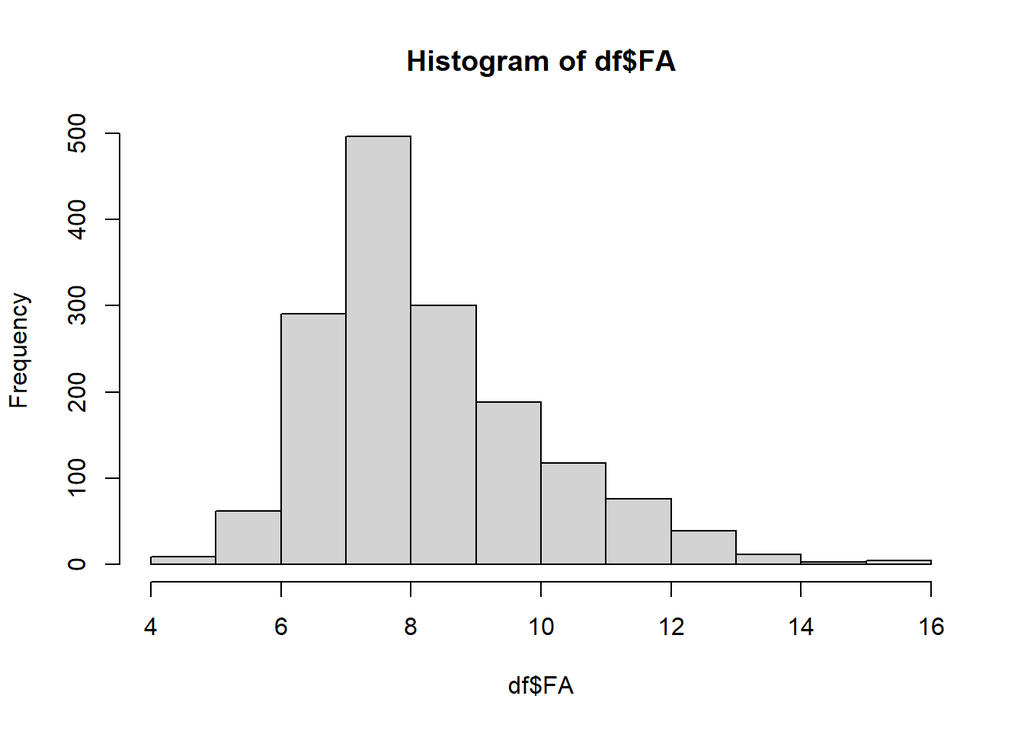

```r
hist(df$FA)
```

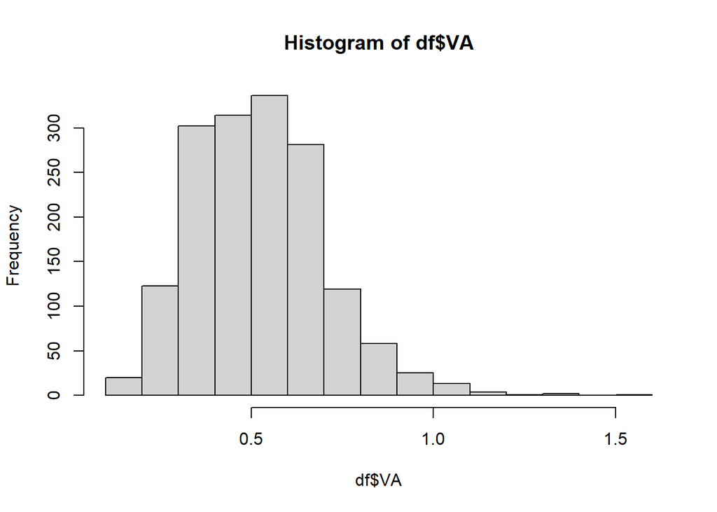

```r
hist(df$VA)
```

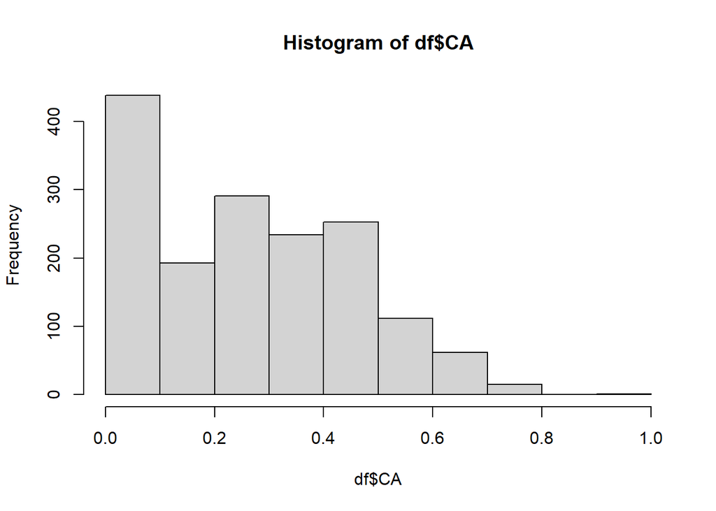

```r
hist(df$CA)
```

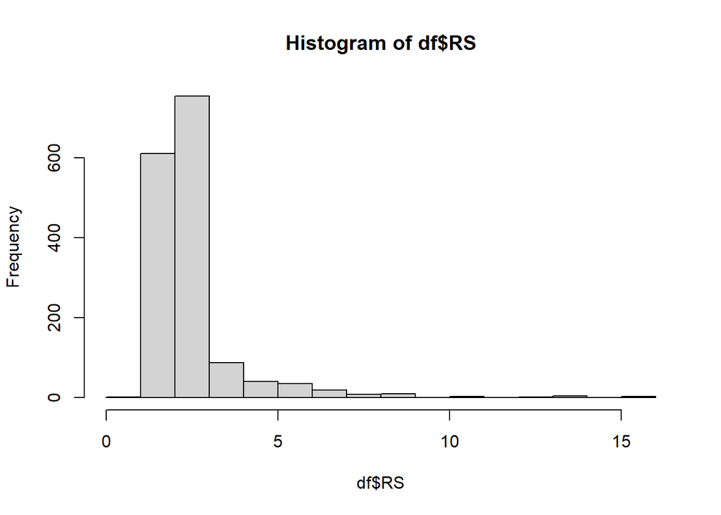

```r
hist(df$RS)
```

```r
stem(df$CH)
```

```
##
##   The decimal point is 1 digit(s) to the left of the |
##
##   0 | 1134444444444444444444
##   0 | 55555555555555555555555555555555555555555555555555555555555555555555+1182
##   1 | 00000000000000000000000000000000000000000000000000000000000000000000+165
##   1 | 5555556666677777777777888999
##   2 | 0111111223334444
##   2 | 5677
##   3 | 3444
##   3 | 66779
##   4 | 001112222
##   4 | 67
##   5 |
##   5 |
##   6 | 11
```

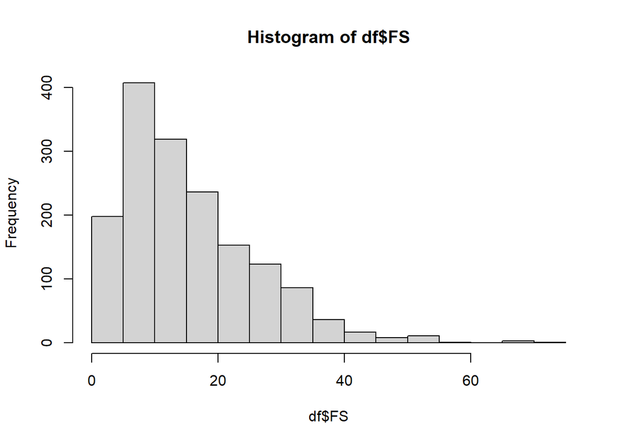

```r
hist(df$FS)
```

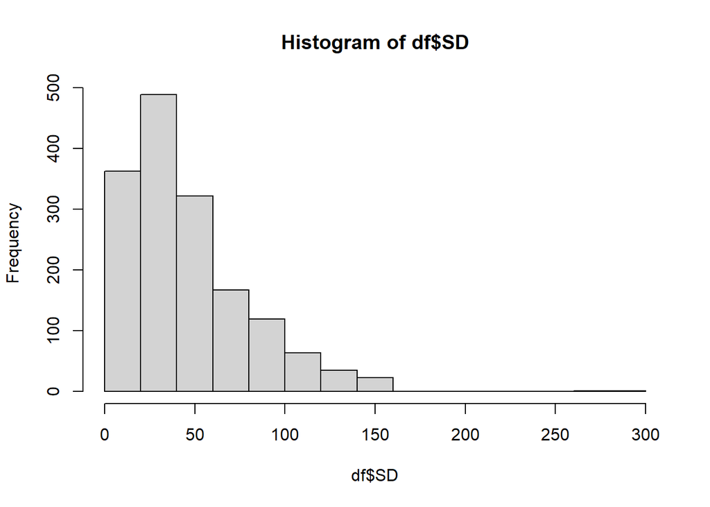

```r
hist(df$SD)
```

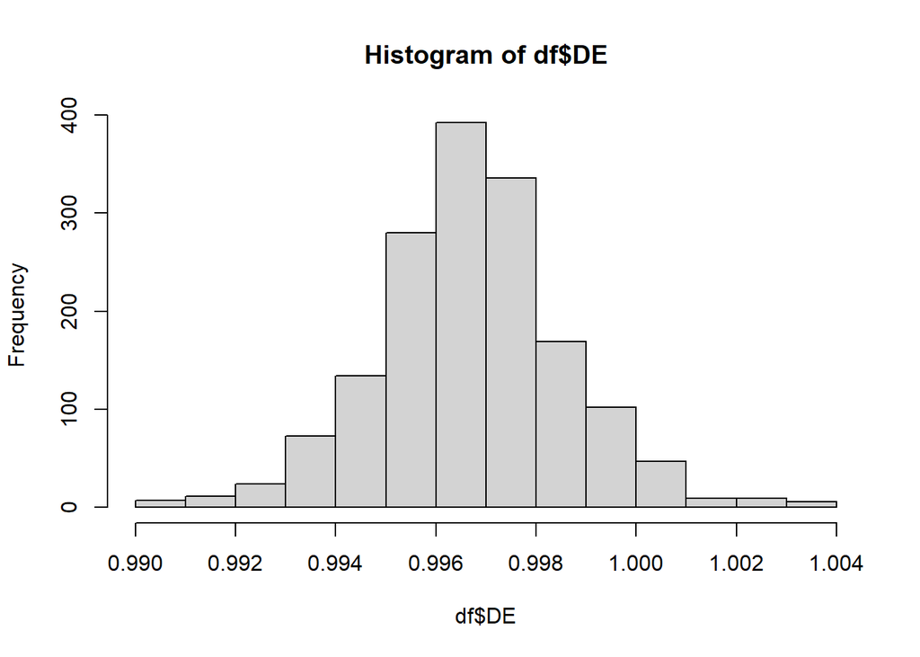

```r
hist(df$DE)
```

```r
stem(df$PH)
```

```
##
##   The decimal point is at the |
##
##   0 | 0111113334
##   0 | 5
##   1 |
##   1 |
##   2 |
##   2 | 79999999999999999999
##   3 | 00000000000000000000000000000000000000000001111111111111111111111111+1212
##   3 | 55555555555555555555555555555555555555555555555555555555555555555555+186
##   4 | 00
##   4 |
##   5 | 0
##   5 | 7
##   6 | 0
##   6 | 5
##   7 | 14
##   7 | 9
##   8 | 2
```

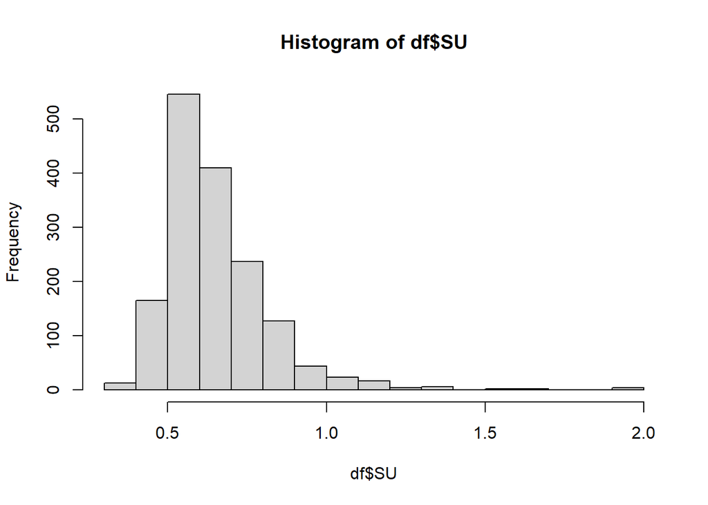

```r
hist(df$SU)
```

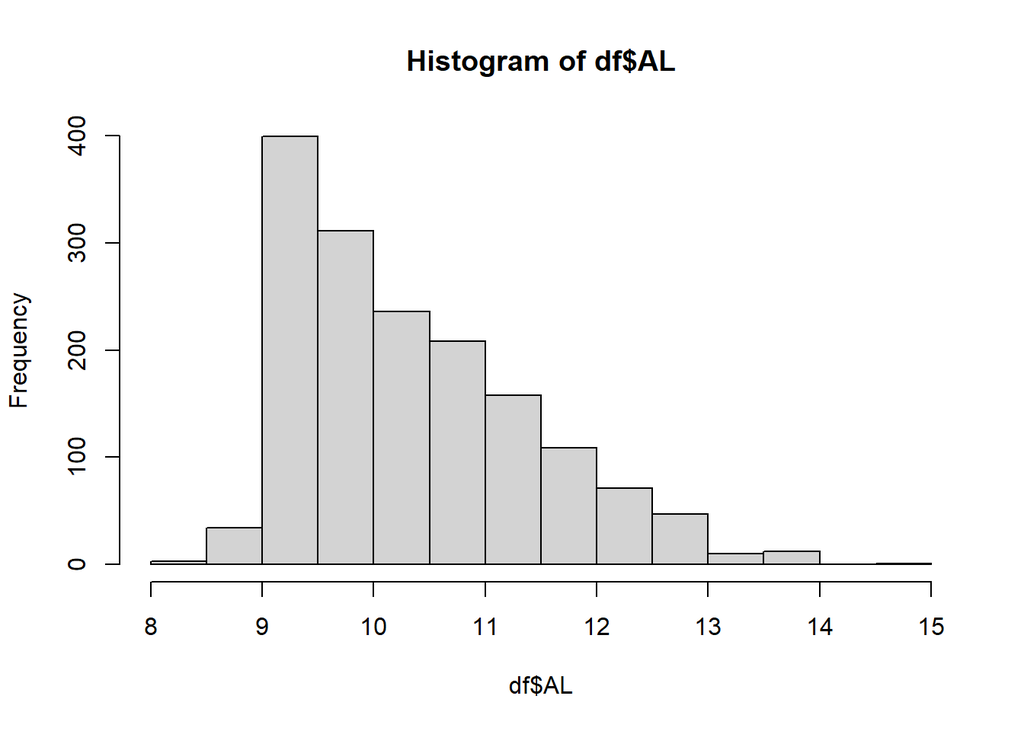

```r
hist(df$AL)
```

### 1(b)

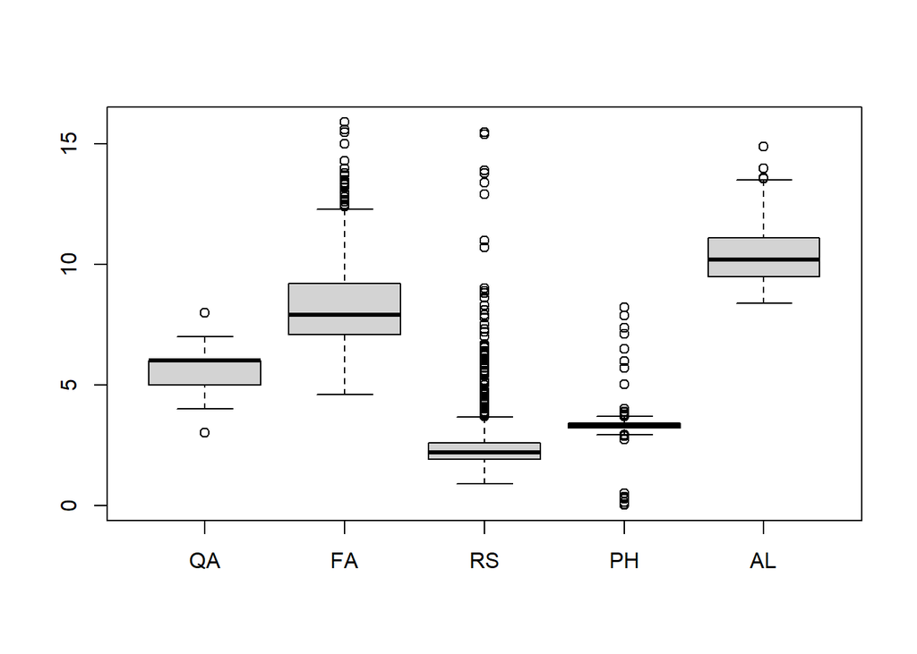

```r
boxplot(df[, c(1, 2, 5, 10, 12)])
```

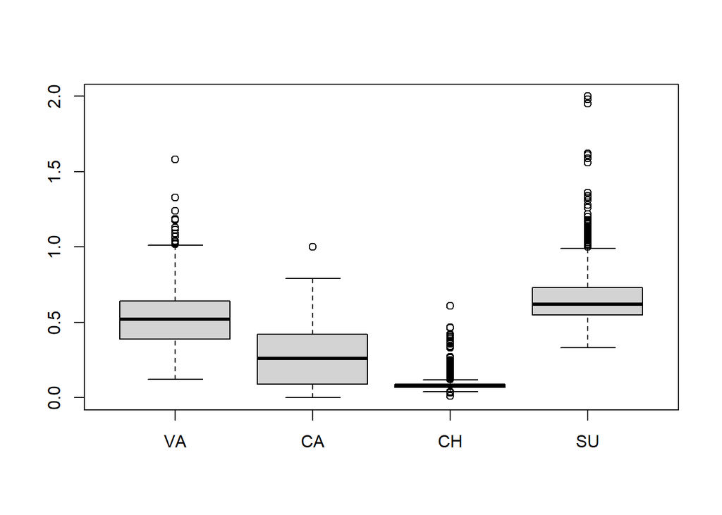

```r
boxplot(df[, c(3, 4, 6, 11)])
```

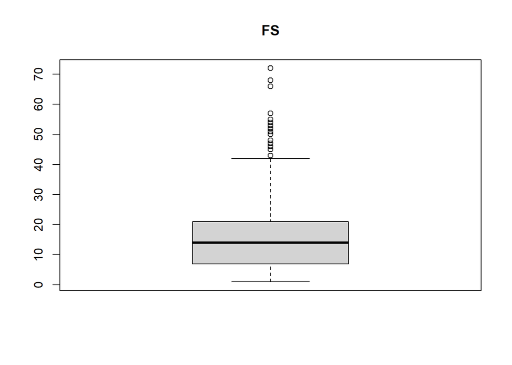

```r
boxplot(df[, c(7)], main = "FS")
```

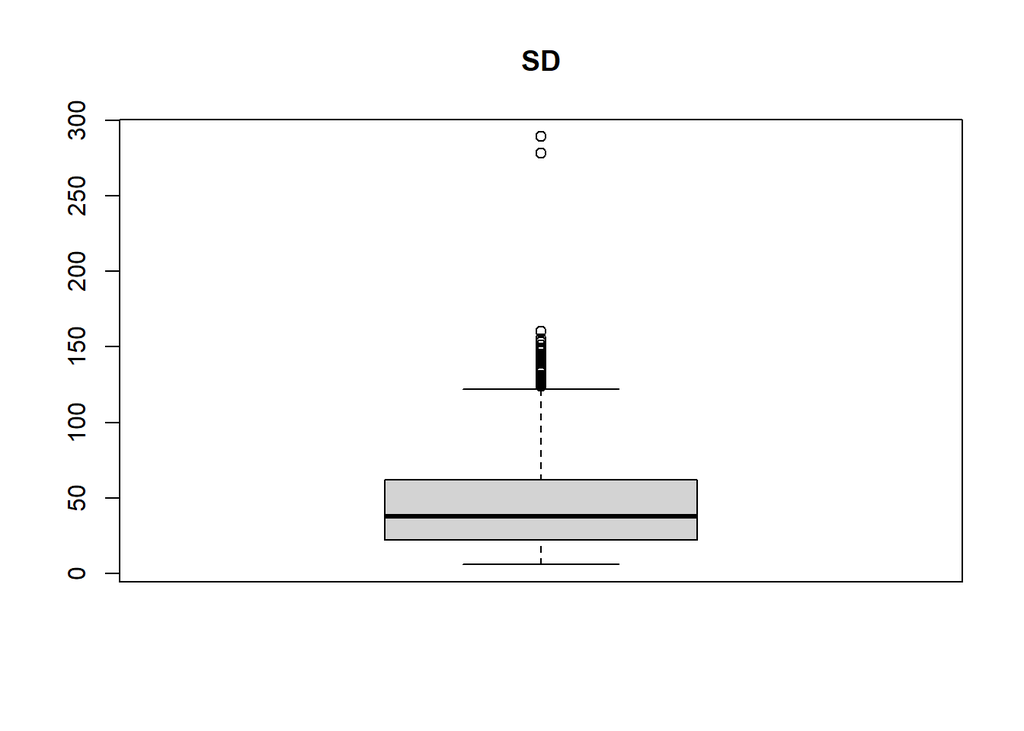

```r
boxplot(df[, c(8)], main = "SD")
```

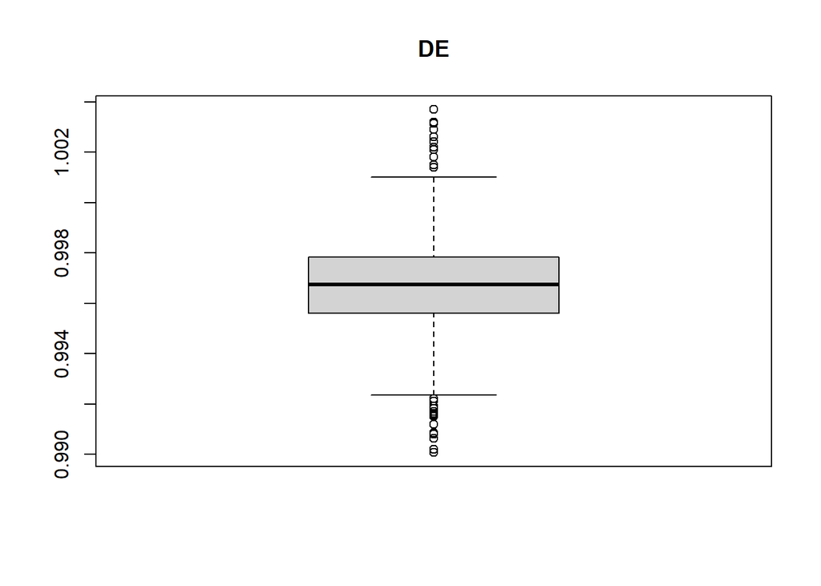

```r
boxplot(df[, c(9)], main = "DE")
```

### 1(c)

```r
library(e1071)
for (column in 1:ncol(df)) {
  cat("Column: ", colnames(df)[column], "\n", "skewness: ",
      skewness(df[, column]),
      "\n",
      "kurtosis: ",
      kurtosis(df[, column]),
      "\n")
}
```

```
## Column:  QA
##  skewness:  0.2173931
##  kurtosis:  0.2879148
## Column:  FA
##  skewness:  0.9809084
##  kurtosis:  1.119699
## Column:  VA
##  skewness:  0.6703331
##  kurtosis:  1.212689
## Column:  CA
##  skewness:  0.3177403
##  kurtosis:  -0.7930455
## Column:  RS
##  skewness:  NA
##  kurtosis:  NA
## Column:  CH
##  skewness:  5.669694
##  kurtosis:  41.52596
## Column:  FS
##  skewness:  1.248222
##  kurtosis:  2.007221
## Column:  SD
##  skewness:  NA
##  kurtosis:  NA
## Column:  DE
##  skewness:  0.07115397
##  kurtosis:  0.9225
## Column:  PH
##  skewness:  0.7893898
##  kurtosis:  69.51551
## Column:  SU
##  skewness:  2.424118
##  kurtosis:  11.66153
## Column:  AL
##  skewness:  0.8592144
##  kurtosis:  0.1916586
```

As we can see from the output above:  
FA:  
- Right skewed  
RS:  
- Heavy skew  
- Heavy outliers  
CH:  
- Highly right skewed  
- Heavy right tail  
FS:  
- Highly right skewed  
SD:  
- Heavy skew  
- Heavy outliers  
PH:  
- Right skewed  
- Heavy right tail  
SU:  
- Highly right skewed  
- Heavy right tail  
AL:  
- Right skewed

### 1(d)

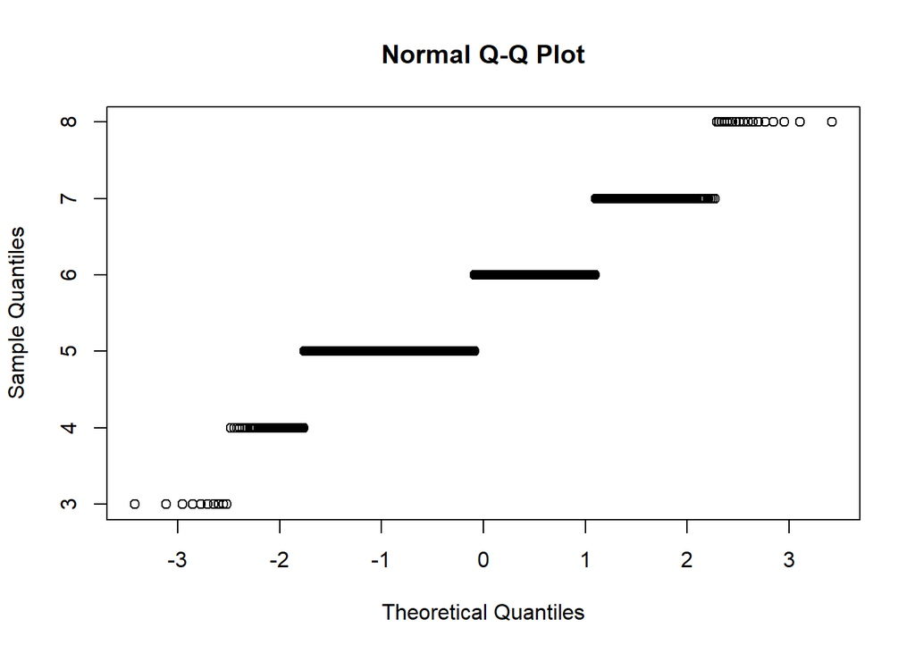

```r
qqnorm(df$QA)
```

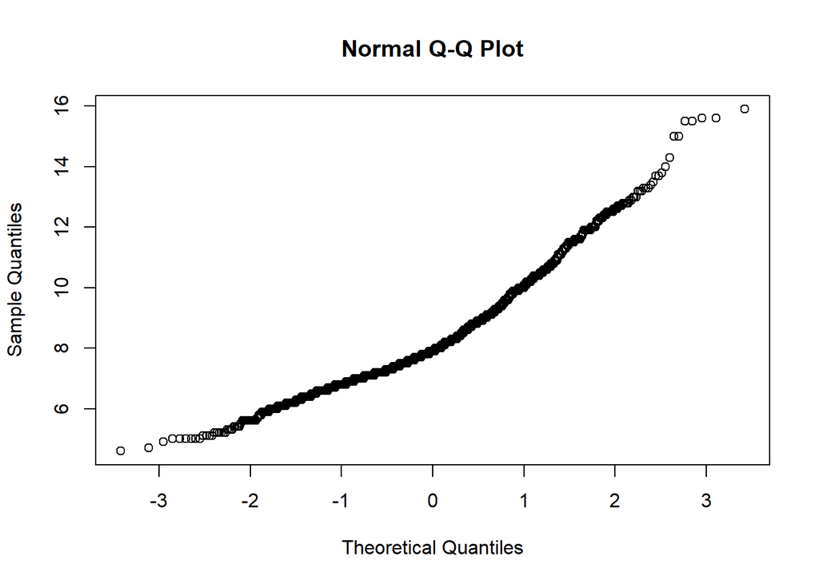

```r
qqnorm(df$FA)
```

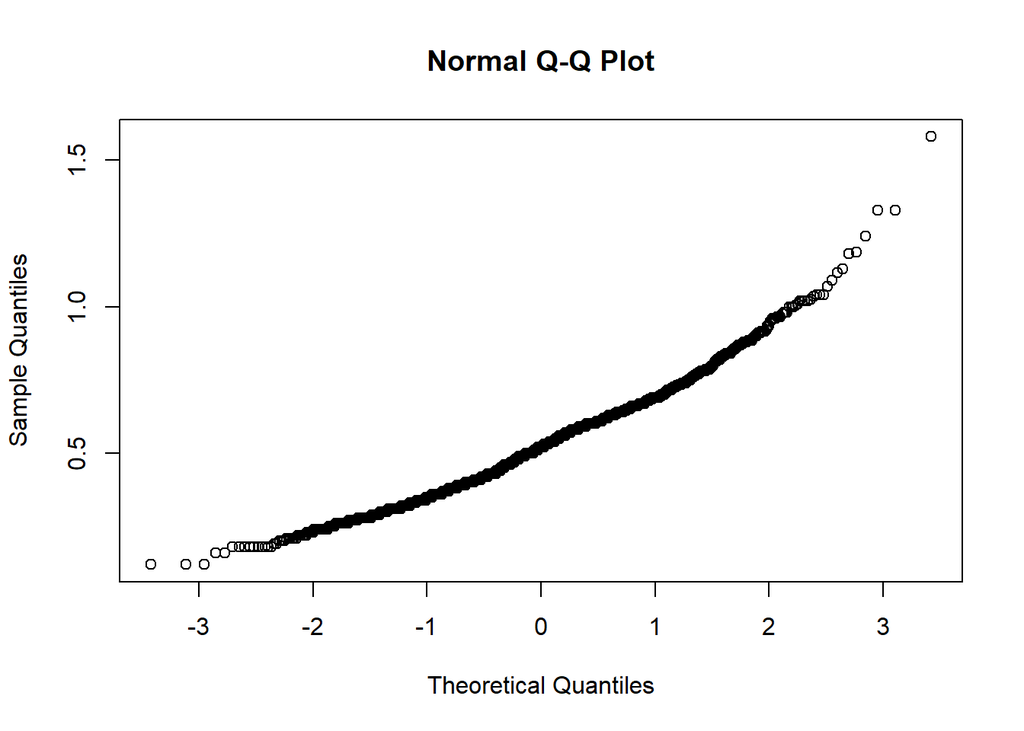

```r
qqnorm(df$VA)
```

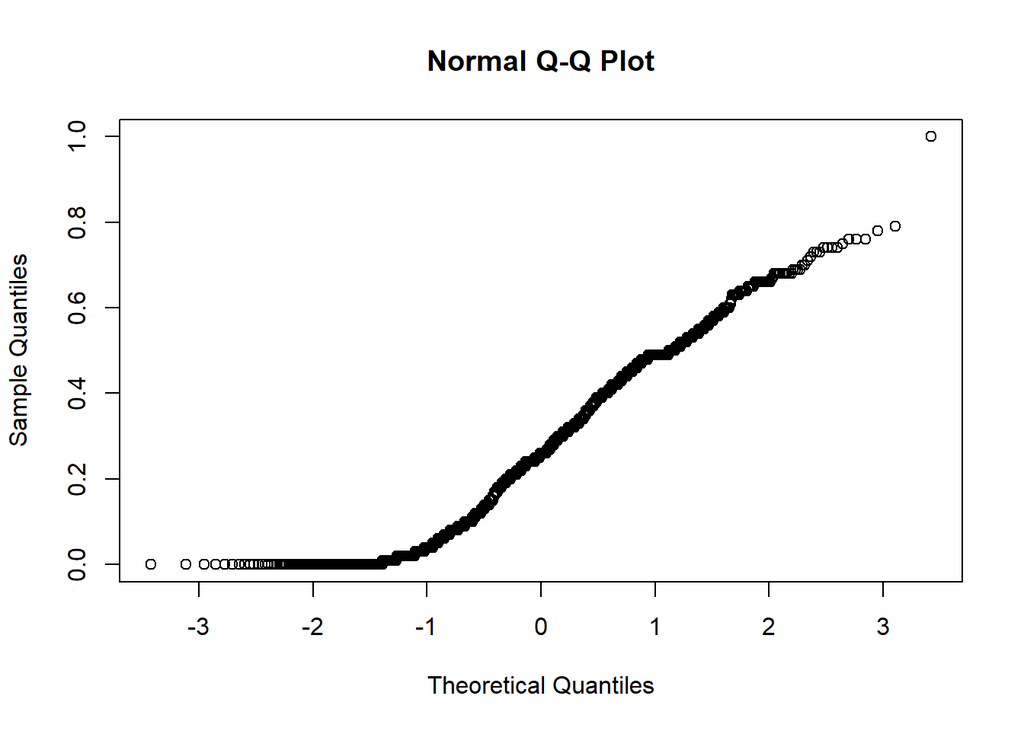

```r
qqnorm(df$CA)
```

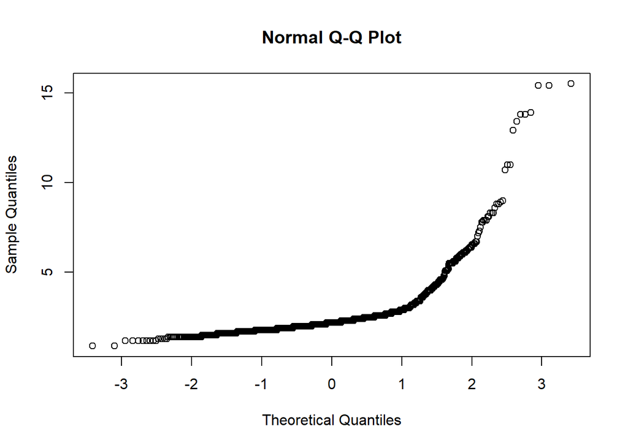

```r
qqnorm(df$RS)
```

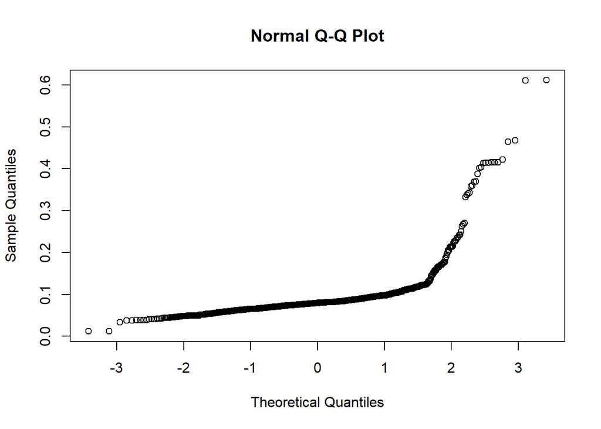

```r
qqnorm(df$CH)
```

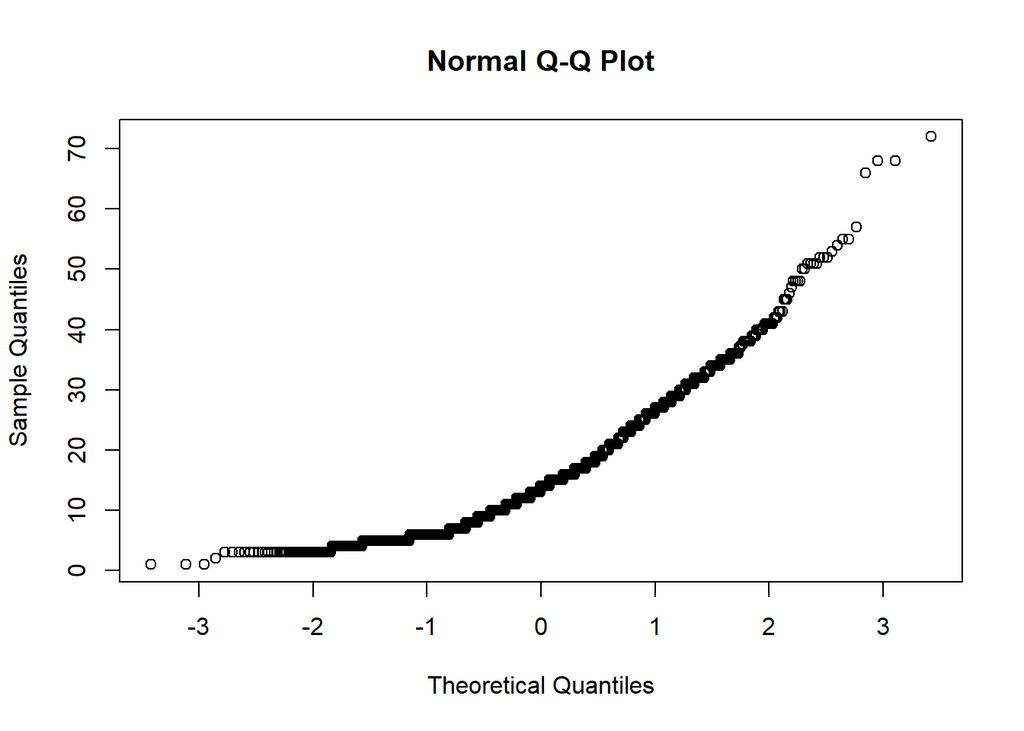

```r
qqnorm(df$FS)
```

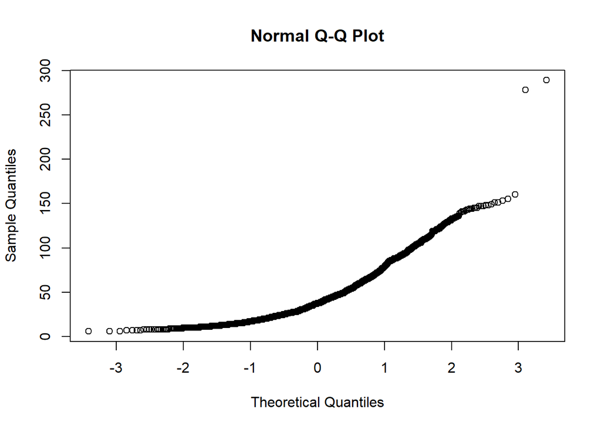

```r
qqnorm(df$SD)
```

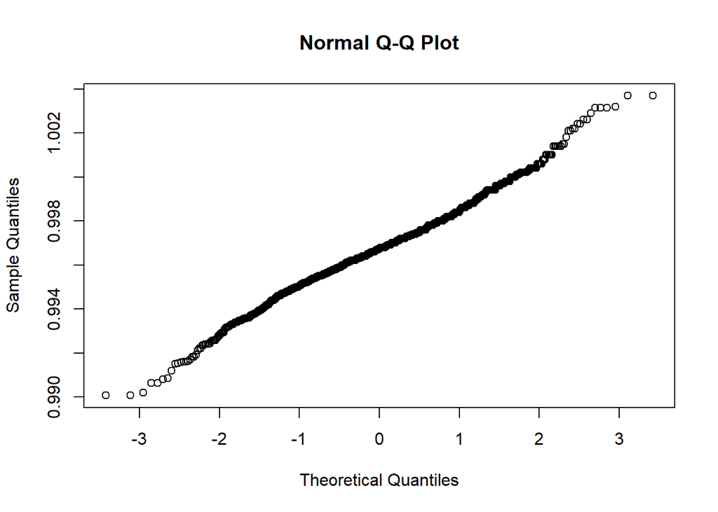

```r
qqnorm(df$DE)
```

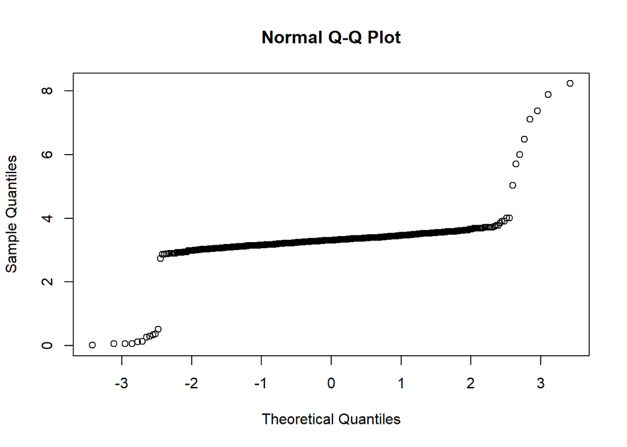

```r
qqnorm(df$PH)
```

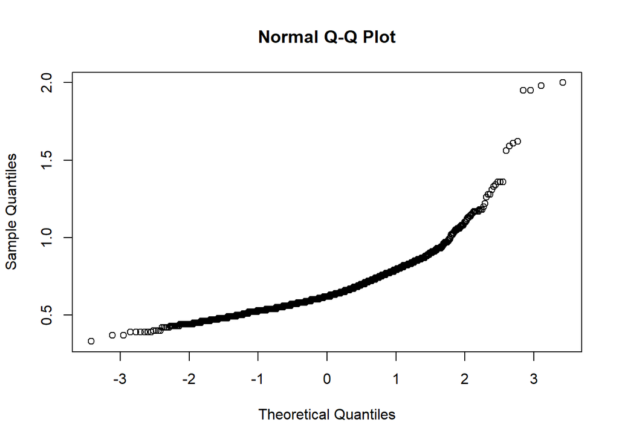

```r
qqnorm(df$SU)
```

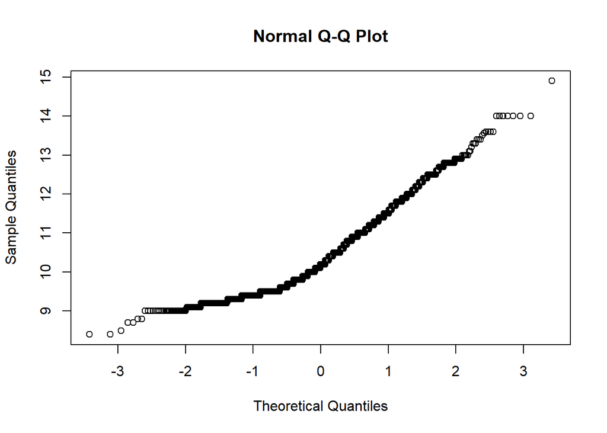

```r
qqnorm(df$AL)
```

Yes, these confirm my conclusions from the previous question.

# Question 2

### 2(a)

```r
colSums(is.na(df))
```

```
## QA FA VA CA RS CH FS SD DE PH SU AL
##  0  0  0  0 22  0  0 17  0  0  0  0
```

RS and SD have missing values.

```r
sum(rowSums(is.na(df)))
```

```
## [1] 39
```

There are 39 rows with missing values.

### 2(b)

#### Create folds

```r
library(caret)
set.seed(1)
n_folds = 5
folds = createFolds(1:nrow(df), k = n_folds)
```

#### Impute data function

```r
random_impute = function (a) {
  missing_values = is.na(a)
  # number of missing values
  number_missing_values = sum(missing_values)
  a.obs = a[!missing_values]
  imputed = a
  # sample with replacement
  imputed[missing_values] = sample(a.obs,
                                   number_missing_values,
                                   replace=T)
  return(imputed)
}
```

#### Linear regression models

```r
set.seed(1)
mse_train = rep(NA, n_folds)
mse_test  = rep(NA, n_folds)
for (fold in 1:n_folds) {
  train = df[-folds[[fold]],]
  test  = df[folds[[fold]],]

  train = random_impute(train)
  test  = random_impute(test)

  fit = lm(QA ~ ., data = train)
  preds_train = predict(fit, train)
  preds_test  = predict(fit, test)

  mse_train[fold] = mean((train$QA - preds_train)^2)
  mse_test[fold]  = mean((test$QA - preds_test)^2)
}
avg_mse_train = mean(mse_train)
avg_mse_test  = mean(mse_test)
```

Average train MSE: 0.41723  
Average test MSE: 0.42892

### 2(c)

#### Impute data function (Mode)

```r
Mode = function(x) {
  mode = as.numeric(names(sort(table(x),decreasing=T))[1])
  return(mode)
}

mode_impute = function (a){
  missing_values = is.na(a)
  imputed = a
  imputed[missing_values] = Mode(a)
  return(imputed)
}
```

#### Linear regression models

```r
set.seed(1)
mse_train = rep(NA, n_folds)
mse_test  = rep(NA, n_folds)
for (fold in 1:n_folds) {
  train = df[-folds[[fold]],]
  test  = df[folds[[fold]],]

  train$SD = mode_impute(train$SD)
  train$RS = mode_impute(train$RS)
  test$SD  = mode_impute(test$SD)
  test$RS  = mode_impute(test$RS)

  fit = lm(QA ~ ., data = train)
  preds_train = predict(fit, train)
  preds_test  = predict(fit, test)

  mse_train[fold] = mean((train$QA - preds_train)^2)
  mse_test[fold]  = mean((test$QA - preds_test)^2)
}
avg_mse_train = mean(mse_train)
avg_mse_test  = mean(mse_test)
```

Average train MSE: 0.41684  
Average test MSE: 0.42857

### 2(d)

```r
avg_impute = function (a){
  missing = is.na(a)
  imputed = a
  imputed[missing] = mean(a, na.rm=T)
  return(imputed)
}
```

#### Linear regression models

```r
set.seed(1)
mse_train = rep(NA, n_folds)
mse_test  = rep(NA, n_folds)
for (fold in 1:n_folds) {
  train = df[-folds[[fold]],]
  test  = df[folds[[fold]],]

  train$SD = avg_impute(train$SD)
  train$RS = avg_impute(train$RS)
  test$SD  = avg_impute(test$SD)
  test$RS  = avg_impute(test$RS)

  fit = lm(QA ~ ., data = train)
  preds_train = predict(fit, train)
  preds_test  = predict(fit, test)

  mse_train[fold] = mean((train$QA - preds_train)^2)
  mse_test[fold]  = mean((test$QA - preds_test)^2)
}
avg_mse_train = mean(mse_train)
avg_mse_test  = mean(mse_test)
```

Average train MSE: 0.41671  
Average test MSE: 0.42862

### 2(e)

#### Linear regression models

```r
library(DMwR)
set.seed(1)
mse_train = rep(NA, n_folds)
mse_test  = rep(NA, n_folds)
for (fold in 1:n_folds) {
  train = df[-folds[[fold]],]
  test  = df[folds[[fold]],]

  train = knnImputation(train, k=5, distData = train)
  test = knnImputation(test, k=5, distData = test)

  fit = lm(QA ~ ., data = train)
  preds_train = predict(fit, train)
  preds_test  = predict(fit, test)

  mse_train[fold] = mean((train$QA - preds_train)^2)
  mse_test[fold]  = mean((test$QA - preds_test)^2)
}
avg_mse_train = mean(mse_train)
avg_mse_test  = mean(mse_test)
```

Average train MSE: 0.41665  
Average test MSE: 0.4285

### 2(f)

#### Linear regression models

```r
library(mice)
set.seed(1)
mse_train = rep(NA, n_folds)
mse_test  = rep(NA, n_folds)
for (fold in 1:n_folds) {
  train = df[-folds[[fold]],]
  test  = df[folds[[fold]],]

  train = complete(mice(train, seed=1, print=F), 5)
  test  = complete(mice(test,  seed=1, print=F), 5)

  fit = lm(QA ~ ., data = train)
  preds_train = predict(fit, train)
  preds_test  = predict(fit, test)

  mse_train[fold] = mean((train$QA - preds_train)^2)
  mse_test[fold]  = mean((test$QA - preds_test)^2)
}
avg_mse_train = mean(mse_train)
avg_mse_test  = mean(mse_test)
```

Average train MSE: 0.41699  
Average test MSE: 0.42898

### 2(g)

#### Linear regression models

```r
set.seed(1)
mse_train = rep(NA, n_folds)
mse_test  = rep(NA, n_folds)
for (fold in 1:n_folds) {
  train = df[-folds[[fold]],]
  test  = df[folds[[fold]],]

  train = train[complete.cases(train), ]
  test  = test[complete.cases(test), ]

  fit = lm(QA ~ ., data = train)
  preds_train = predict(fit, train)
  preds_test  = predict(fit, test)

  mse_train[fold] = mean((train$QA - preds_train)^2)
  mse_test[fold]  = mean((test$QA - preds_test)^2)
}
avg_mse_train = mean(mse_train)
avg_mse_test  = mean(mse_test)
```

Average train MSE: 0.41956  
Average test MSE: 0.43115

### 2(h)

All of the different data imputations methods performed very similarly. This is probably because there weren’t too many missing values in the first place.

KNN with nearest neighbors set to 5 performed the best by a tiny bit. The margin is so small that I think it doesn’t mean anything actually. With other data the result could slightly skew in the favor of another data imputation method.